# Forecasting Project 1 - Group 7

# 1. Introduction

This project is a forecasting analysis for the electricity exports from Switzerland to several European countries. The data used was all provided by the professor and no additional datasets were used. We have selected the models that fit each country the best (based on some performance metrics) and have created forecasts and CI’s for each country as well as the total. In the final report you are now reading, only the most important information is included, and whatever was deemed unnecessary for the report you can find in our code files/appendix.

The forecasting models used in this project are S-Naive, S-ARIMA and ETS.

# 2. Data Processing

The data we were given was already cleaned, without any missing values. The only noteworthy cleaning we did, was to format the names of all columns and all rows, and to then convert the final table to a tsibble in order to be able to use functions from the tsibble and fpp3 package. All details on how this was done can be found in the code files.

# 3. Exploratory Data Analysis

## 3.1 Historical data plots

In this section you can find an example of the exploratory analysis we did to identify outliers and behaviors in our data. We created historical plots of all the data for each country, but this is not presented here and can instead be found in our appendix. The anomalies and outliers we discovered in that section, were used to guide our analysis.

For example, we noticed irregularities in the amplitudes of seasonality over time. For countries like Germany and France, the amplitude of the seasonality seemed to increase towards the most recent years. Based on this, we decided to do a seasonal/trend decomposition for each country to further analyze this.

Furthermore, for Lichtenstein, we noticed a huge drop in exports after 2008-2009, which can not be explain by the historical data. In order to handle it, we use different approachs such as splitting the data or implementing piece wise model.

## 3.2 Seasonal Sub-series plots

We also created seasonal sub-series plots to explore specific months in more detail, for each country. Below you can see the one for the total exports:

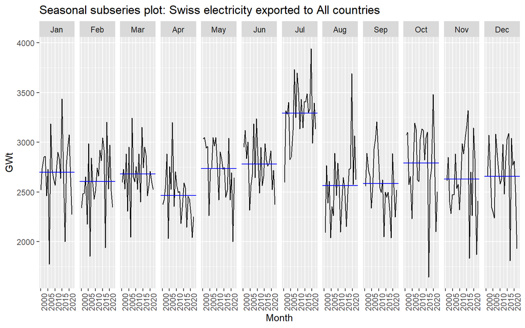

```r
data_elec %>% gg_subseries(Total) +
    ylab("GWt") + xlab("Month") +
    ggtitle("Seasonal subseries plot: Swiss electricity exported to All countries")
```

Here are some observations based on these plots for each country (which you can find in appendix):

- Germany: It looks like Germany consistently receives more electricity during the summer months (May, June, July, August). Seasonality seems to vary over time, increasing towards the most recent years.
- France: It looks like there are two peaks in energy exported to France during the year, one in July, and one in December.
- Italy: Similar energy peak in July.
- Austria: Same trend, with a single peak in the summer months, and then relatively constant energy for the other months.
- Lichtenstein: This country shows the opposite trend, with a very smooth peak in the coldest winter months (Jan,Feb), and the lowest energy exports during the summer months.
- Total: Clearly seeing the peak in energy exports to countries in the summer, and specifically in July. The other months are at similar levels for the total electricity exports.

In summary, the main observation we got from these historical plots, was that all countries (except Lichtenstein) experience peaks in the electricity they receive from Switzerland in the summer months.

Before this monthly analysis, we expected that energy exports to these countries, would be higher in the winter months, as that’s when people tend to consume more energy to heat up their homes (we assumed this to be one of the biggest drivers in energy consumption). However, in reality it seems like electricity exports are peaking in the summer and not in the winter months. Our explanation for this is that the ways to heat up a home in the winter are mainly based on oil/gas rather than electricity which is why there is no peak for electricity exports in the winter. On the contrary, during the summer months, people tend to cool down their homes using Air-conditioning which primarily uses electricity, hence the peak in the summer months. This does not explain why Lichtenstein does not follow the same pattern, despite being geographically right next to all of these countries (hence having similar climate).

## 3.3 ACF - Autocorrelation analysis

Before moving on with the models and in order to be able to use them, we wanted to check for autocorrelation in the time series. Here is data on Germany which is lagged by 12 periods:

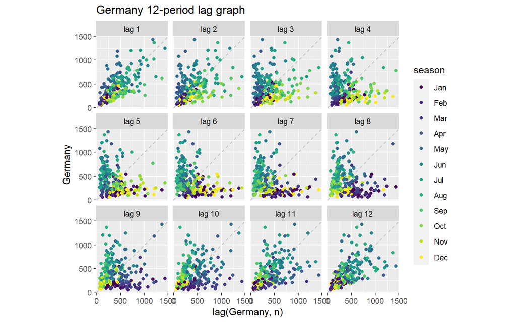

```r
#Graph of 12 lagged months for Germany
data_elec %>%
  gg_lag(Germany, lags = 1:12, geom="point") +
  ggtitle("Germany 12-period lag graph")
```

From this graph, we can visualize autocorrelation. It’s clear that the autocorrelation is the highest for the 1-month lag, and the 12-month lag. We can see this because the points in the first and last scatterplot (Current month vs Lagged period) approach the 45-degree line, indicating the similarity in magnitude of two the observations.

Based on the strong and clear presence of autocorrelation, we expect that a model like ARIMA/SARIMA will do a good job to capture this auto-correlation component, and will most likely have the best performance compared to other models. On the contrary, auto-correlation tends to impact the performance of SNAIVE models, as they rely on the assumption that the future values are solely determined by past values without considering any auto-correlation patterns. This suggests that our SNAIVE model will not be fitting the data as well.

## 3.4 STL Decomposition for all countries

We decided to perform an STL decomposition, as it can provide valuable insights and help explore and understand any strange patterns in our data.

Overall as you can see below, we observed strong seasonality and trend patterns in each country and all countries together which suggested our models should have a way to capture the presence of seasonality and trend. This can be seen in the trend + season_year graphs which show the trend + seasonal component in relation to the overall variation in the data (this is seen using the grey box on the left of each graph). Finally, we can also see that the “remainder” component is quite significant in size (relative to the overall variation) which makes the time series difficult to predict accurately.

### **Germany**

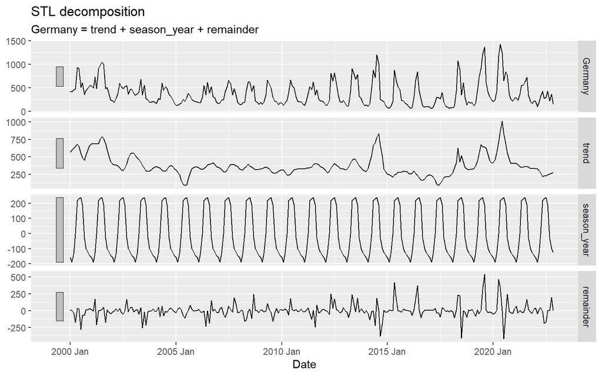

```r
data_elec %>%
  model(STL(Germany ~ trend(window = 7) + season(window = "periodic"),
    robust = TRUE)) %>%
  components() %>%
  autoplot()
```

### **France**

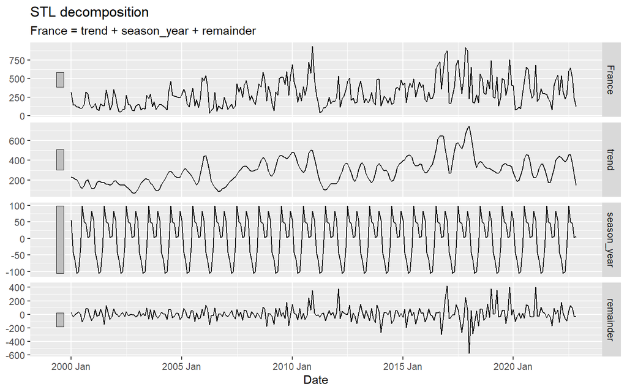

```r
#STL Decomposition_France
data_elec %>%
  model(STL(France ~ trend(window = 7) + season(window = "periodic"),
    robust = TRUE)) %>%
  components() %>%
  autoplot()
```

### **Italy**

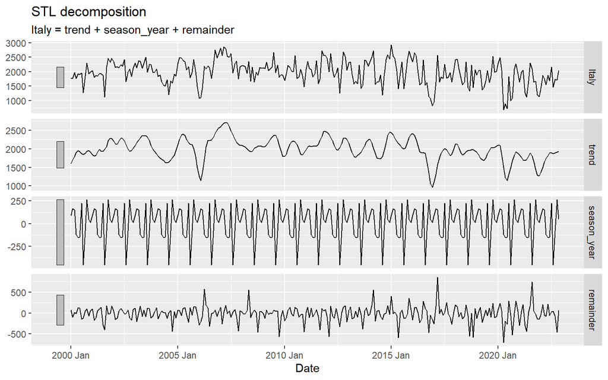

```r
data_elec %>%
  model(STL(Italy ~ trend(window = 7) + season(window = "periodic"),
    robust = TRUE)) %>%
  components() %>%
  autoplot()
```

### **Austria**

Austria trend undergoes a huge increase during the period 2018-2021, follow by a significant drop which are not explainable by historical data and strongly suggest that it is affected by a covariate. Seasonality is constant and stable over time during the whole period.

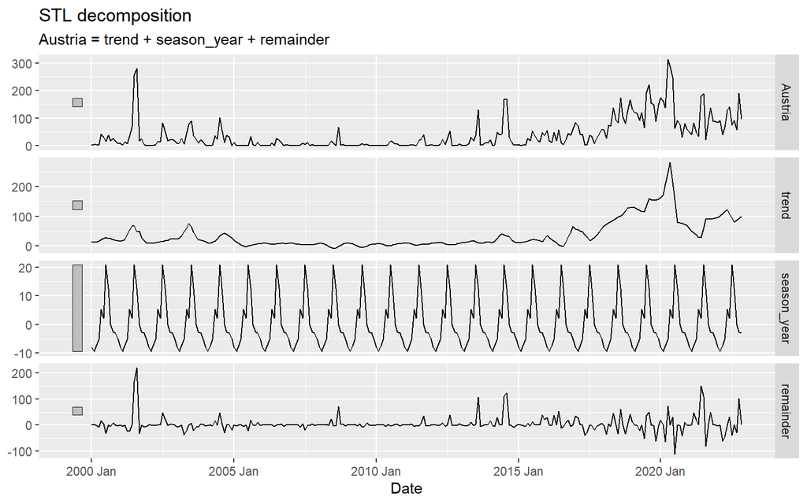

```r
data_elec %>%
  model(STL(Austria ~ trend(window = 7) + season(window = "periodic"),
    robust = TRUE)) %>%
  components() %>%
  autoplot()
```

### **Lichtenstein**

Lichtenstein trend undergoes a drastical drop during the year of 2008, that is not explainable by historical data and strongly suggest that it is affected by a covariate. Seasonality is constant and stable over time during the whole period. Thus we observe that the amplitude and duration of the seasonal patterns remain unchanged over different time periods.

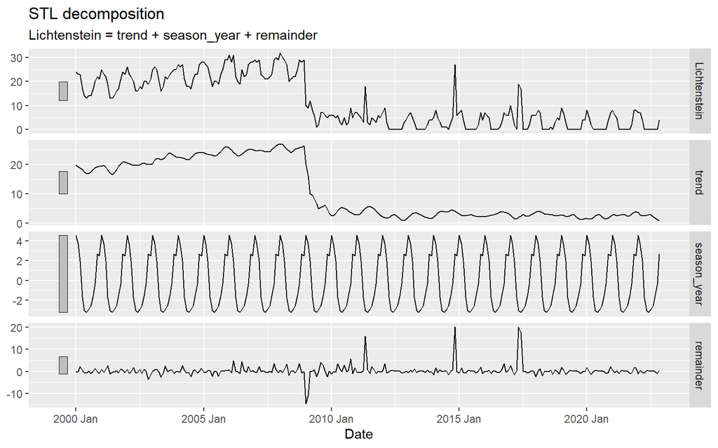

```r
data_elec %>%
  model(STL(Lichtenstein ~ trend(window = 7) + season(window = "periodic"),
    robust = TRUE)) %>%
  components() %>%
  autoplot()
```

### **Total**

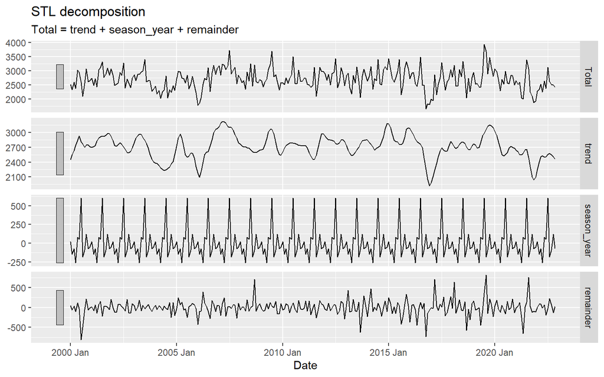

```r
data_elec %>%
  model(STL(Total ~ trend(window = 7) + season(window = "periodic"),
    robust = TRUE)) %>%
  components() %>%
  autoplot()
```

## 3.5 Unit Root Test for Stationarity

In the final part of our EDA, we wanted to confirm our suspicion of the presence of non-stationarity (since we found a significant trend and seasonal component in the STL analysis). To do this, we used the Unit Root Test to check for the presence of a unit root in the time series, which is an indication of non-stationarity. Below are the null and alternative hypotheses for this statistical test:

$$H_0: The\ time\ series\ has\ a\ unit\
root\ (non\ stationary)\\ H_1: The\ time\ series\ is\
stationary$$

After doing the test for all countries, we found that all of the time series (except Lichtenstein) are stationary at a significance level of: `alpha = 0.05`. This is against our initial assumption that the data is non-stationary, which was based on the fact that we saw a clear trend and seasonality for many of the countries. When the data is stationary, any model can be used (stationarity in the data is one of the assumptions for NAIVE and ETS models). However for Lichtenstein, since the p-value is larger than our significance level of 5%, we have to difference or log the Lichtenstein data before using some models.

### **Germany**

The test statistic was -6.3865. The p-value of the test was 0.01, which indicates strong evidence to reject the null hypothesis of non-stationarity at `alpha = 0.05`. Thus Germany data is a stationary time series.

```
##
##  Augmented Dickey-Fuller Test
##
## data:  ts_g
## Dickey-Fuller = -6.3865, Lag order = 6, p-value = 0.01
## alternative hypothesis: stationary
```

### **France**

The test statistic was -5.671 The p-value of the test was 0.01, which indicates strong evidence to reject the null hypothesis of non-stationarity at `alpha = 0.05`. Thus France data is a stationary time series.

```
##
##  Augmented Dickey-Fuller Test
##
## data:  ts_F
## Dickey-Fuller = -5.671, Lag order = 6, p-value = 0.01
## alternative hypothesis: stationary
```

### **Italy**

The test statistic was -6.1852 The p-value of the test was 0.01. Thus Italy data is a stationary time series.

```
##
##  Augmented Dickey-Fuller Test
##
## data:  ts_I
## Dickey-Fuller = -6.1852, Lag order = 6, p-value = 0.01
## alternative hypothesis: stationary
```

### **Austria**

The test statistic was -3.6792 The p-value of the test was 0.02595, which indicates strong evidence to reject the null hypothesis of non-stationarity at `alpha = 0.05`. Thus Austria data is a stationary time series.

```
##
##  Augmented Dickey-Fuller Test
##
## data:  ts_A
## Dickey-Fuller = -3.6792, Lag order = 6, p-value = 0.02595
## alternative hypothesis: stationary
```

### **Lichtenstein**

The test statistic was -3.0063. The p-value of the test was 0.1521. Thus Lichtenstein data is a NON stationary time series.

```
##
##  Augmented Dickey-Fuller Test
##
## data:  ts_Lich
## Dickey-Fuller = -3.0063, Lag order = 6, p-value = 0.1521
## alternative hypothesis: stationary
```

### **Total**

Finally, The test statistic was -4.8658 The p-value of the test was 0.01. Thus Total data is a stationary time series.

```
##
##  Augmented Dickey-Fuller Test
##
## data:  ts_Tot
## Dickey-Fuller = -4.8658, Lag order = 6, p-value = 0.01
## alternative hypothesis: stationary
```

# 4. Model Selection

## Methodology

Before creating forecasts, we wanted to discover which model fits our data the best. To evaluate this, we have decided to fit different models for each country, and then pick the best one.

To do this, we split our data into a training and a test set. The first one we will use to estimate any parameters of the forecasting model, and the second is to examine each model’s accuracy. The training set for all countries is basically a long time period, from the beginning of our data until the end of 2015, and then the rest of the data is used in the test set.

The different models we decided to explore are S-ARIMA, ETS and S-NAIVE, and we used them to forecast 60 periods (months) and then compare those with the data in the test set.

Models automatically select the optimal parameters by searching through different combinations and selecting the best model based on a predefined criterion. We don’t specify their parameters manually.

For each country, we selected the model with the best accuracy metrics, as we will explain below. Some of the metrics we will look at are RMSE and MAE and low metric values indicate a better predictive performance of the model. A value of 0 indicates a perfect fit between the predicted and actual values. Residuals analysis is also going to be plotted to see how well the model captures the dynamics of the data. Good models’ residuals should be stationary (white noise) and have no patterns.

As the most accurate forecast is of interest, we will give more weight to the model with low values of RMSE and MAE, even though another model has a higher AIC (see Appendix 2.).

## 4.1 Germany

```r
Germany_since_2015 <- data_elec %>%
  select(Date,Germany) %>%
  suppressWarnings(filter(Date >= as.Date("2015-01-01")))
```

### **Testing Models**

Below is the plot of how well each model fits the data based on a 60-period prediction starting from 2016.

```r
#Split the data
training_ge <- data_elec %>% select(Date,Germany) %>% filter(Date < as.Date("2016-01-01"))
test_ge <- data_elec %>% select(Date,Germany) %>% filter(Date >= as.Date("2016-01-01"))
```

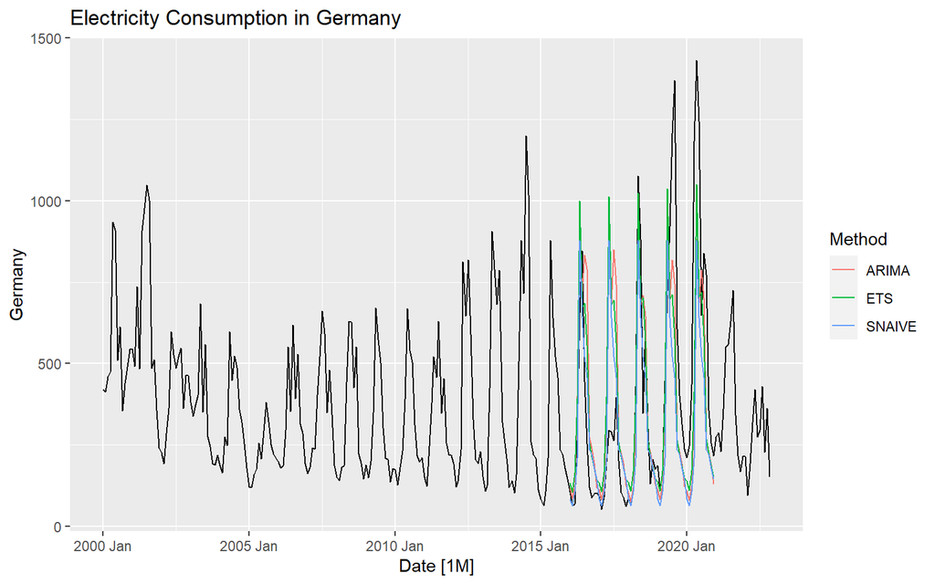

```r
# Fit ARIMA model and generate forecasts
data_fit_ge_a <- training_ge %>%
  model(ARIMA(Germany))
forecasts_ge_a <- data_fit_ge_a %>%
  forecast(h = 60)

# Fit ETS model and generate forecasts
data_fit_ge_e <- training_ge %>%
  model(ETS(Germany))
forecasts_ge_e <- data_fit_ge_e %>%
  forecast(h = 60)

# Fit seasonal naive model and generate forecasts
data_fit_ge_n <- training_ge %>%
  model(SNAIVE(Germany))
forecasts_ge_n <- data_fit_ge_n %>%
  forecast(h = 60)

# Combine forecasts into a single data frame
all_forecasts_ge <- bind_rows(
  data.frame(Date = forecasts_ge_a$Date, Method = "ARIMA", Forecast = forecasts_ge_a$.mean),
  data.frame(Date = forecasts_ge_e$Date, Method = "ETS", Forecast = forecasts_ge_e$.mean),
  data.frame(Date = forecasts_ge_n$Date, Method = "SNAIVE", Forecast = forecasts_ge_n$.mean))


# Plot all three sets of forecasts together
data_elec %>% autoplot(Germany)  +
  geom_line(data = all_forecasts_ge, aes(x = Date, y = Forecast, color = Method)) +
  labs(title = "Electricity Consumption in Germany")
```

### **Measuring Model Accuracy**

```r
#Accuracy
germany_accuracy_a <- accuracy(forecasts_ge_a, test_ge)

germany_accuracy_e <- accuracy(forecasts_ge_e, test_ge)

germany_accuracy_n <- accuracy(forecasts_ge_n, test_ge)

germany_accuracy_table <- rbind(
  data.frame(germany_accuracy_a),
  data.frame(germany_accuracy_e),
  data.frame(germany_accuracy_n))
```

| .model | .type | ME | RMSE | MAE | MPE | MAPE | MASE | RMSSE | ACF1 |
| --- | --- | --- | --- | --- | --- | --- | --- | --- | --- |
| ARIMA(Germany) | Test | 22.21212 | 271.7830 | 191.6002 | -21.98723 | 57.15420 | NaN | NaN | 0.6419235 |
| ETS(Germany) | Test | 20.06976 | 263.9592 | 183.7753 | -26.84302 | 57.48681 | NaN | NaN | 0.5797918 |
| SNAIVE(Germany) | Test | 92.46667 | 285.7502 | 190.6667 | -1.86239 | 49.34599 | NaN | NaN | 0.6260558 |

```r
#AIC
report(data_fit_ge_a)
```

```
## Series: Germany
## Model: ARIMA(1,0,1)(2,1,1)[12]
##
## Coefficients:
##          ar1      ma1     sar1     sar2    sma1
##       0.7853  -0.2946  -0.8231  -0.4046  0.0965
## s.e.  0.0731   0.1106   0.1925   0.1247  0.2054
##
## sigma^2 estimated as 15296:  log likelihood=-1124.06
## AIC=2260.11   AICc=2260.6   BIC=2279.27
```

```r
report(data_fit_ge_e)
```

```
## Series: Germany
## Model: ETS(M,N,M)
##   Smoothing parameters:
##     alpha = 0.3739358
##     gamma = 0.3451097
##
##   Initial states:
##      l[0]      s[0]     s[-1]     s[-2]    s[-3]    s[-4]    s[-5]    s[-6]
##  653.4368 0.6246774 0.7255761 0.7347587 1.011001 1.387123 1.493534 1.469065
##     s[-7]     s[-8]    s[-9]    s[-10]    s[-11]
##  1.560156 0.7932617 0.864902 0.6433645 0.6925801
##
##   sigma^2:  0.094
##
##      AIC     AICc      BIC
## 2797.057 2799.784 2845.919
```

### **Residuals**

The output below also suggests that the ARIMA model did well in capturing all the dynamics in data, as the residuals seem to be white noise.

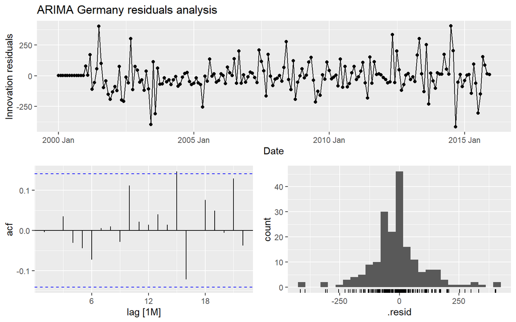

```r
gg_tsresiduals(data_fit_ge_a) + labs(title = "ARIMA Germany residuals analysis")
```

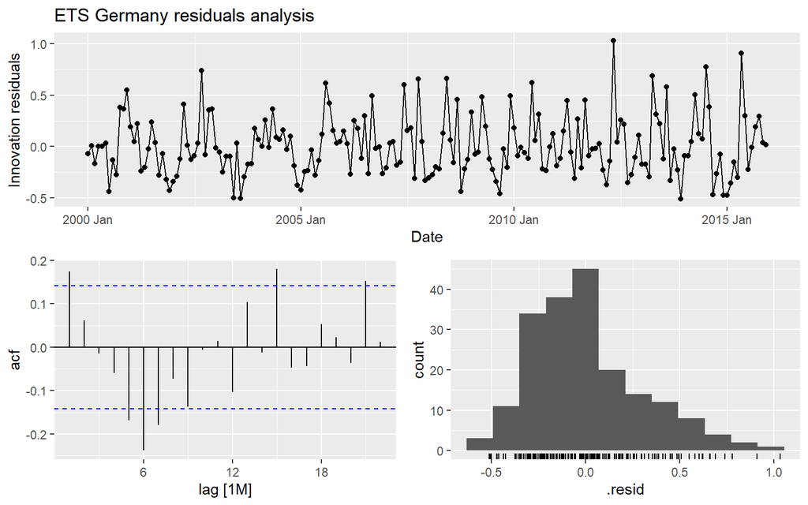

```r
gg_tsresiduals(data_fit_ge_e) + labs(title = "ETS Germany residuals analysis")
```

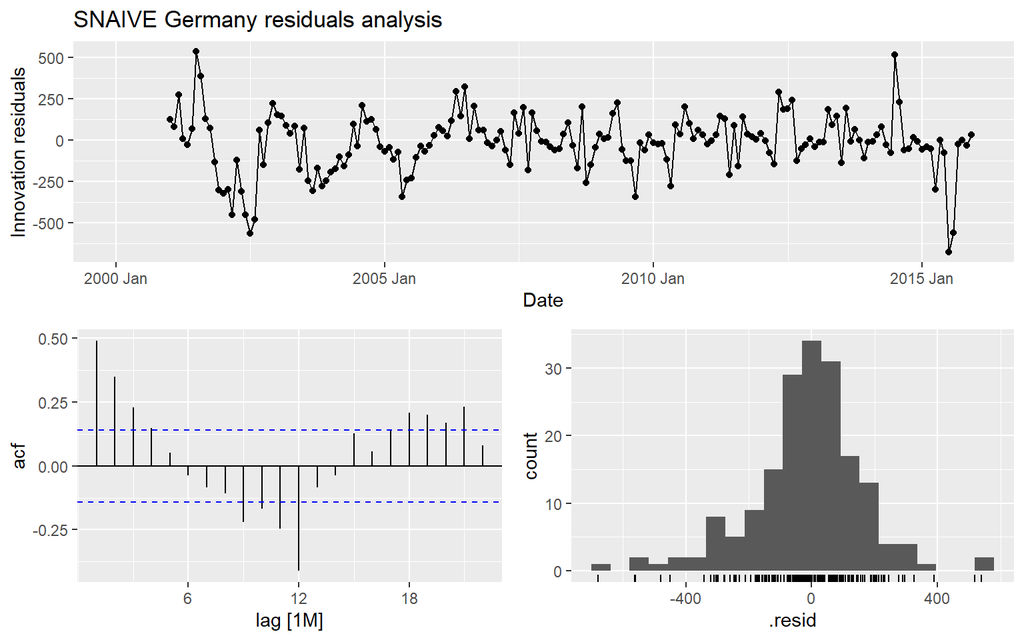

```r
gg_tsresiduals(data_fit_ge_n) + labs(title = "SNAIVE Germany residuals analysis")
```

## 4.2 Italy

```r
#Selecting Italy only since 2018 to better display the forecast. 2018 will both show the trend BEFORE covid + improve display
Italy_since_2018 <- data_elec %>% select(Date,Italy) %>% filter(Date >= as.Date("2018-01-01"))
```

### **Testing Models**

Below is the plot of how well each model fits the data based on a 60-period prediction starting from 2016.

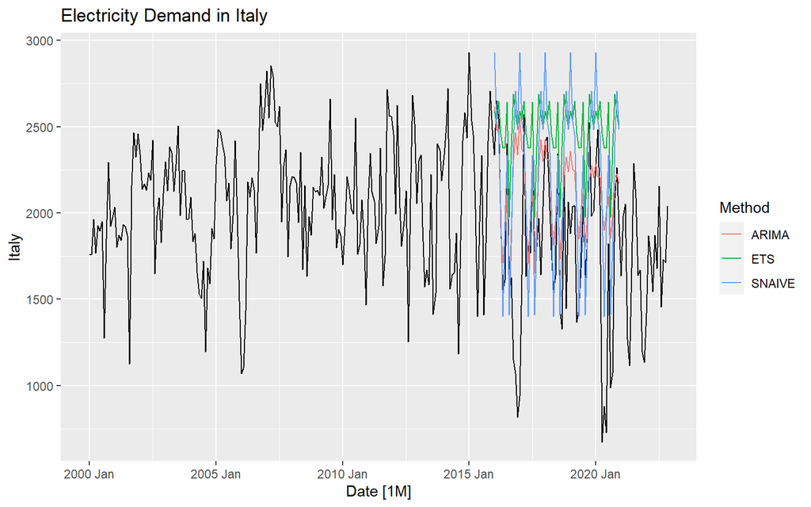

```r
#Split the data
training_it <- data_elec %>% select(Date, Italy) %>%  filter(Date < as.Date("2016-01-01"))
test_it <- data_elec %>% select(Date, Italy) %>% filter(Date >= as.Date("2016-01-01"))

# Fit ARIMA model and generate forecasts
data_fit_it_a <- training_it %>%
  model(ARIMA(Italy))
forecasts_it_a <- data_fit_it_a %>%
  forecast(h = 60)


# Fit ETS model and generate forecasts
data_fit_it_e <- training_it %>%
  model(ETS(Italy))
forecasts_it_e <- data_fit_it_e %>%
  forecast(h = 60)

# Fit seasonal naive model and generate forecasts
data_fit_it_n <- training_it %>%
  model(SNAIVE(Italy))
forecasts_it_n <- data_fit_it_n %>%
  forecast(h = 60)

# Combine forecasts into a single data frame
all_forecasts_it <- bind_rows(
  data.frame(Date = forecasts_it_a$Date, Method = "ARIMA", Forecast = forecasts_it_a$.mean),
  data.frame(Date = forecasts_it_e$Date, Method = "ETS", Forecast = forecasts_it_e$.mean),
  data.frame(Date = forecasts_it_n$Date, Method = "SNAIVE", Forecast = forecasts_it_n$.mean))


# Plot all three sets of forecasts together
data_elec %>% autoplot(Italy) +
  geom_line(data = all_forecasts_it, aes(x = Date, y = Forecast, color = Method)) +
  labs(title = "Electricity Demand in Italy")
```

### **Measuring Model Accuracy**

According to the accuracy table below, RMSE, MAE, as well as AIC, AICc, and BIC, ARIMA has the lowest values on the test data than the ETS model.

```r
#Accuracy
italy_accuracy_a <-accuracy(forecasts_it_a, test_it)

italy_accuracy_e <-accuracy(forecasts_it_e, test_it)

italy_accuracy_n <-accuracy(forecasts_it_n, test_it)

italy_accuracy_table <- rbind(
  data.frame(italy_accuracy_a),
  data.frame(italy_accuracy_e),
  data.frame(italy_accuracy_n))
```

| .model | .type | ME | RMSE | MAE | MPE | MAPE | MASE | RMSSE | ACF1 |
| --- | --- | --- | --- | --- | --- | --- | --- | --- | --- |
| ARIMA(Italy) | Test | -326.2634 | 567.8518 | 397.3082 | -29.97463 | 32.99264 | NaN | NaN | 0.5201659 |
| ETS(Italy) | Test | -684.9666 | 814.8247 | 688.7554 | -51.88364 | 52.02657 | NaN | NaN | 0.5512166 |
| SNAIVE(Italy) | Test | -412.1667 | 655.4941 | 479.4667 | -33.06326 | 36.73605 | NaN | NaN | 0.4827242 |

```
## Series: Italy
## Model: ARIMA(1,0,0)(2,0,0)[12] w/ mean
##
## Coefficients:
##          ar1    sar1    sar2  constant
##       0.6369  0.3471  0.3479  227.4524
## s.e.  0.0565  0.0673  0.0717   16.0636
##
## sigma^2 estimated as 73103:  log likelihood=-1349.39
## AIC=2708.77   AICc=2709.1   BIC=2725.06
```

```
## Series: Italy
## Model: ETS(A,N,A)
##   Smoothing parameters:
##     alpha = 0.7893584
##     gamma = 0.0001000066
##
##   Initial states:
##      l[0]     s[0]    s[-1]    s[-2]     s[-3]    s[-4]    s[-5]    s[-6]
##  2001.551 15.17983 90.59285 210.0609 -95.62885 -503.615 165.2749 -103.177
##      s[-7]     s[-8]    s[-9]   s[-10]   s[-11]
##  -101.2201 -20.17958 171.0857 59.06312 112.5631
##
##   sigma^2:  71693.32
##
##      AIC     AICc      BIC
## 3171.492 3174.219 3220.354
```

### **Residuals**

The output below also suggests that the ARIMA model did well in capturing all the dynamics in data, as the residuals seem to be white noise.

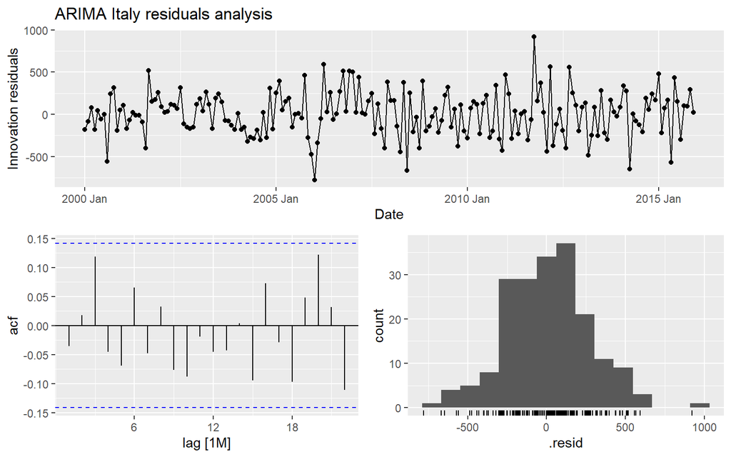

```r
gg_tsresiduals(data_fit_it_a) + labs(title = "ARIMA Italy residuals analysis")
```

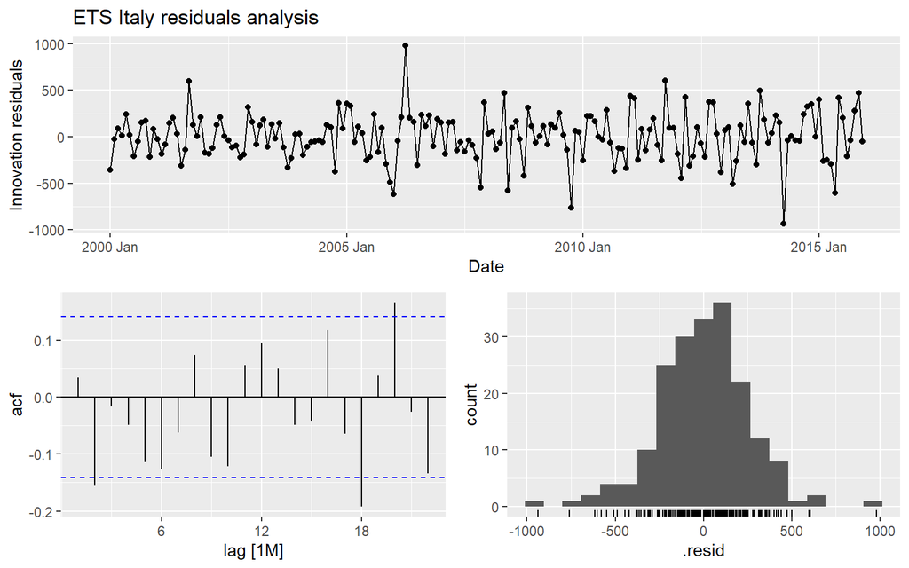

```r
gg_tsresiduals(data_fit_it_e) + labs(title = "ETS Italy residuals analysis")
```

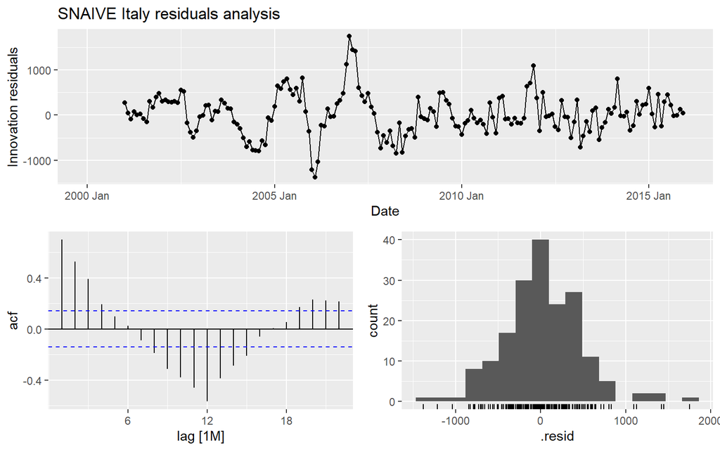

```r
gg_tsresiduals(data_fit_it_n) + labs(title = "SNAIVE Italy residuals analysis")
```

## 4.3 Austria

```r
#Investigating Austria closely since 2018, because it seems like something changed -> perhaps should use Piecewise!!!
Austria_since_2015 <- data_elec %>% select(Date,Austria) %>% filter(Date >= as.Date("2015-01-01"))
Austria_since_2018 <- data_elec %>% select(Date,Austria) %>% filter(Date >= as.Date("2018-02-01"))
```

### **Testing Models**

Below is the plot of how well each model fits the data based on a 60-period prediction starting from 2016.

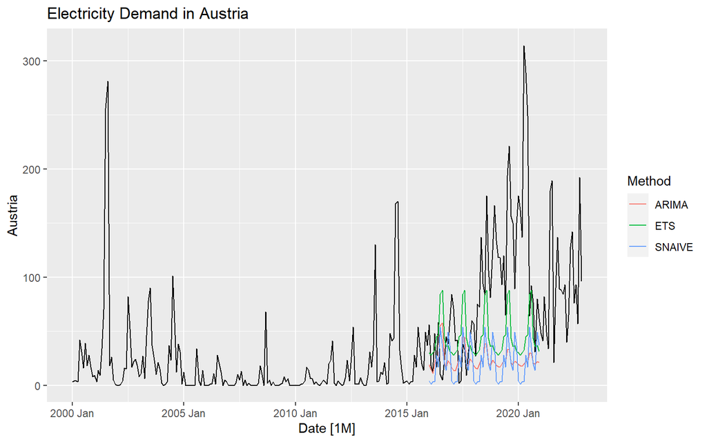

```r
#Split the data
training_au <- data_elec %>% select(Date, Austria) %>%  filter(Date < as.Date("2016-01-01"))
test_au <- data_elec %>% select(Date, Austria) %>% filter(Date >= as.Date("2016-01-01"))

# Fit ARIMA model and generate forecasts
data_fit_au_a <- training_au %>%
  model(ARIMA(Austria, stepwise = FALSE))
forecasts_au_a <- data_fit_au_a %>%
  forecast(h = 60)

# Fit ETS model and generate forecasts
data_fit_au_e <- training_au %>%
  model(ETS(Austria))
forecasts_au_e <- data_fit_au_e %>%
  forecast(h = 60)

# Fit seasonal naive model and generate forecasts
data_fit_au_n <- training_au %>%
  model(SNAIVE(Austria))
forecasts_au_n <- data_fit_au_n %>%
  forecast(h = 60)

# Combine forecasts into a single data frame
all_forecasts_au <- bind_rows(
  data.frame(Date = forecasts_au_a$Date, Method = "ARIMA", Forecast = forecasts_au_a$.mean),
  data.frame(Date = forecasts_au_e$Date, Method = "ETS", Forecast = forecasts_au_e$.mean),
  data.frame(Date = forecasts_au_n$Date, Method = "SNAIVE", Forecast = forecasts_au_n$.mean))


# Plot all three sets of forecasts together
data_elec %>% autoplot(Austria) +
  geom_line(data = all_forecasts_au, aes(x = Date, y = Forecast, color = Method)) +
  labs(title = "Electricity Demand in Austria")
```

### **Measuring Model Accuracy**

```r
#Accuracy
austria_accuracy_a <-accuracy(forecasts_au_a, test_au)

austria_accuracy_e <-accuracy(forecasts_au_e, test_au)

austria_accuracy_n <-accuracy(forecasts_au_n, test_au)

austria_accuracy_table <- rbind(
  data.frame(austria_accuracy_a),
  data.frame(austria_accuracy_e),
  data.frame(austria_accuracy_n))
```

| .model | .type | ME | RMSE | MAE | MPE | MAPE | MASE | RMSSE | ACF1 |
| --- | --- | --- | --- | --- | --- | --- | --- | --- | --- |
| ARIMA(Austria, stepwise = FALSE) | Test | 66.64429 | 96.87947 | 72.54087 | 4.907234 | 115.4226 | NaN | NaN | 0.7391642 |
| ETS(Austria) | Test | 45.52002 | 84.62589 | 61.72927 | -72.600292 | 154.0206 | NaN | NaN | 0.7354246 |
| SNAIVE(Austria) | Test | 67.66667 | 98.50110 | 73.33333 | 14.887570 | 112.9874 | NaN | NaN | 0.7014929 |

```
## Series: Austria
## Model: ARIMA(0,0,3)(2,0,1)[12] w/ mean
##
## Coefficients:
##          ma1     ma2     ma3    sar1    sar2     sma1  constant
##       0.5991  0.1591  0.1055  0.6072  0.0853  -0.3699    6.3202
## s.e.  0.0742  0.0814  0.0731  0.2940  0.1561   0.2850    2.1449
##
## sigma^2 estimated as 796.7:  log likelihood=-911.62
## AIC=1839.24   AICc=1840.03   BIC=1865.3
```

```
## Series: Austria
## Model: ETS(A,N,A)
##   Smoothing parameters:
##     alpha = 0.5246043
##     gamma = 0.0001000228
##
##   Initial states:
##      l[0]      s[0]     s[-1]     s[-2]      s[-3]    s[-4]   s[-5]    s[-6]
##  39.20052 -12.84024 -7.616428 -8.086183 -0.9683645 43.50499 39.8389 2.189109
##      s[-7]     s[-8]     s[-9]    s[-10]    s[-11]
##  0.7038562 -11.55768 -14.38028 -16.43484 -14.35283
##
##   sigma^2:  895.6703
##
##      AIC     AICc      BIC
## 2330.036 2332.764 2378.899
```

### **Residuals**

The output below also suggests that the ARIMA model did well in capturing all the dynamics in data, as the residuals seem to be white noise.

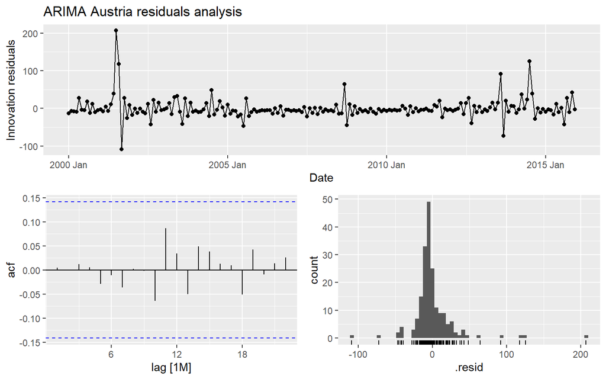

```r
gg_tsresiduals(data_fit_au_a) + labs(title = "ARIMA Austria residuals analysis")
```

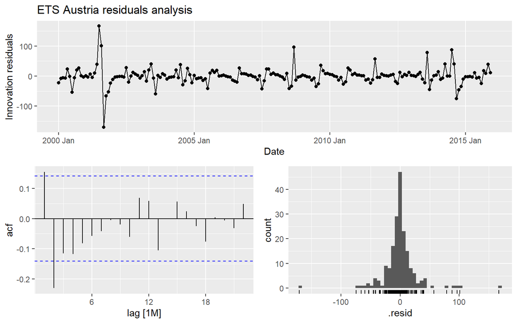

```r
gg_tsresiduals(data_fit_au_e) + labs(title = "ETS Austria residuals analysis")
```

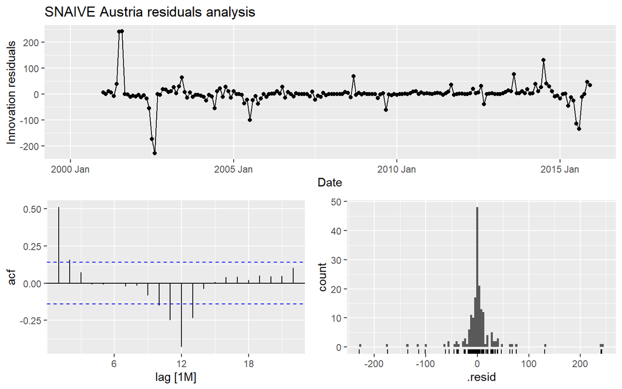

```r
gg_tsresiduals(data_fit_au_n) + labs(title = "SNAIVE Austria residuals analysis")
```

## 4.4 France

```r
France_since_2015 <- data_elec %>% select(Date,France) %>% filter(Date >= as.Date("2015-01-01"))
```

### **Testing Models**

Below is the plot of how well each model fits the data based on a 60-period prediction starting from 2016.

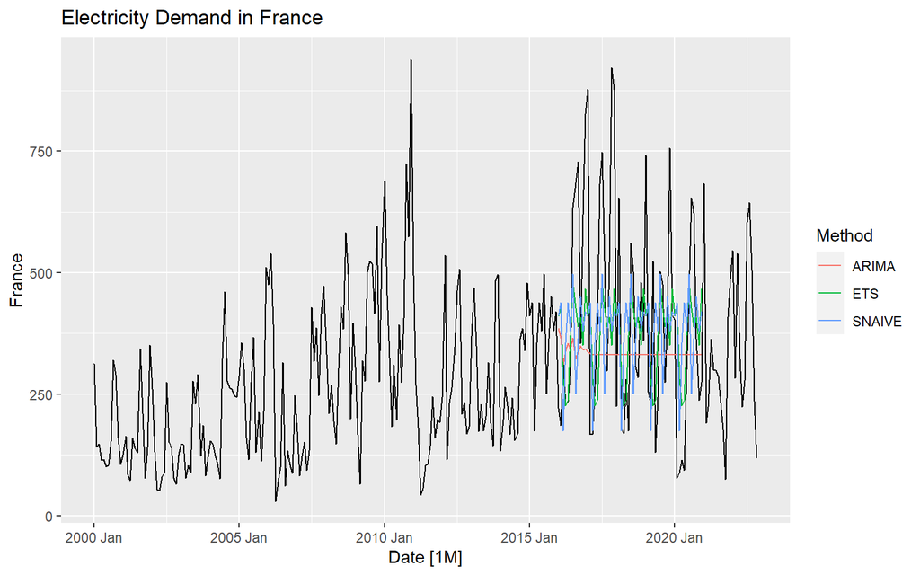

```r
#Split the data
training_fr <- data_elec %>% select(Date, France) %>%  filter(Date < as.Date("2016-01-01"))
test_fr <- data_elec %>% select(Date, France) %>% filter(Date >= as.Date("2016-01-01"))

# Fit ARIMA model and generate forecasts
data_fit_fr_a <- training_fr %>%
  model(ARIMA(France))
forecasts_fr_a <- data_fit_fr_a %>%
  forecast(h = 60)

# Fit ETS model and generate forecasts
data_fit_fr_e <- training_fr %>%
  model(ETS(France))
forecasts_fr_e <- data_fit_fr_e %>%
  forecast(h = 60)

# Fit seasonal naive model and generate forecasts
data_fit_fr_n <- training_fr %>%
  model(SNAIVE(France))
forecasts_fr_n <- data_fit_fr_n %>%
  forecast(h = 60)

# Combine forecasts into a single data frame
all_forecasts_fr <- bind_rows(
  data.frame(Date = forecasts_fr_a$Date, Method = "ARIMA", Forecast = forecasts_fr_a$.mean),
  data.frame(Date = forecasts_fr_e$Date, Method = "ETS", Forecast = forecasts_fr_e$.mean),
  data.frame(Date = forecasts_fr_n$Date, Method = "SNAIVE", Forecast = forecasts_fr_n$.mean))


# Plot all three sets of forecasts together
data_elec %>% autoplot(France) +
  geom_line(data = all_forecasts_fr, aes(x = Date, y = Forecast, color = Method)) +
  labs(title = "Electricity Demand in France")
```

### **Measuring Model Accuracy**

According to the accuracy table below, RMSE, MAE, and other indicators, ETS has the lowest values on the test data. However, ARIMA has lower values of AIC, AICc, and BIC than the ETS model.

```r
#Accuracy
france_accuracy_a <-accuracy(forecasts_fr_a, test_fr)

france_accuracy_e <-accuracy(forecasts_fr_e, test_fr)

france_accuracy_n <-accuracy(forecasts_fr_n, test_fr)

france_accuracy_table <- rbind(
  data.frame(france_accuracy_a),
  data.frame(france_accuracy_e),
  data.frame(france_accuracy_n))
```

| .model | .type | ME | RMSE | MAE | MPE | MAPE | MASE | RMSSE | ACF1 |
| --- | --- | --- | --- | --- | --- | --- | --- | --- | --- |
| ARIMA(France) | Test | 75.45265 | 237.5959 | 188.5761 | -17.89751 | 58.02278 | NaN | NaN | 0.3711334 |
| ETS(France) | Test | 36.97867 | 204.7456 | 161.7681 | -22.58217 | 52.37757 | NaN | NaN | 0.2004276 |
| SNAIVE(France) | Test | 29.75000 | 230.1236 | 188.1500 | -30.72793 | 63.89382 | NaN | NaN | 0.2331056 |

```
## Series: France
## Model: ARIMA(1,1,4)(0,0,1)[12]
##
## Coefficients:
##          ar1      ma1      ma2      ma3      ma4    sma1
##       0.0186  -0.4859  -0.1850  -0.0946  -0.1620  0.1771
## s.e.  0.4208   0.4161   0.2162   0.1137   0.1172  0.0764
##
## sigma^2 estimated as 15135:  log likelihood=-1188.05
## AIC=2390.09   AICc=2390.7   BIC=2412.86
```

```
## Series: France
## Model: ETS(M,N,M)
##   Smoothing parameters:
##     alpha = 0.1672851
##     gamma = 0.0001002813
##
##   Initial states:
##     l[0]     s[0]     s[-1]    s[-2]   s[-3]   s[-4]    s[-5]     s[-6]
##  170.609 1.250038 0.9416617 1.095887 1.04379 1.14645 1.291704 0.9937027
##      s[-7]     s[-8]     s[-9]  s[-10]   s[-11]
##  0.6362197 0.6065504 0.7543347 1.13727 1.102391
##
##   sigma^2:  0.2439
##
##      AIC     AICc      BIC
## 2844.032 2846.759 2892.894
```

### **Residuals**

The output below also suggests that the ARIMA model did well in capturing all the dynamics in data, as the residuals seem to be white noise.

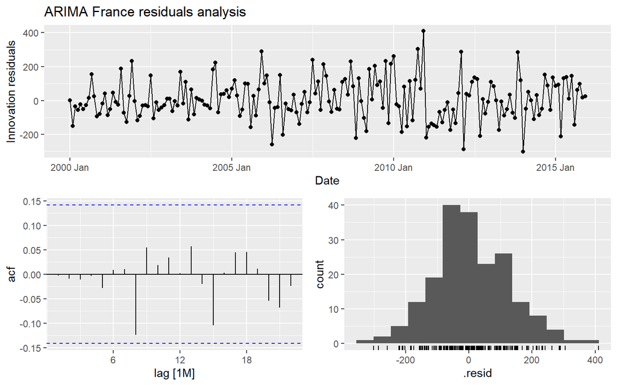

```r
gg_tsresiduals(data_fit_fr_a) + labs(title = "ARIMA France residuals analysis")
```

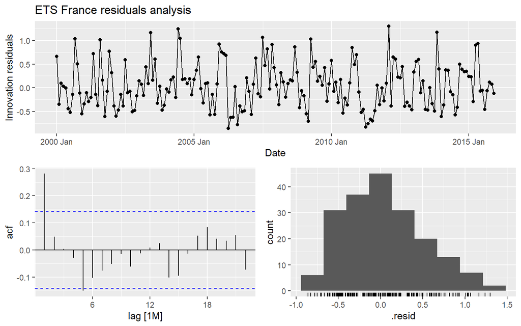

```r
gg_tsresiduals(data_fit_fr_e) + labs(title = "ETS France residuals analysis")
```

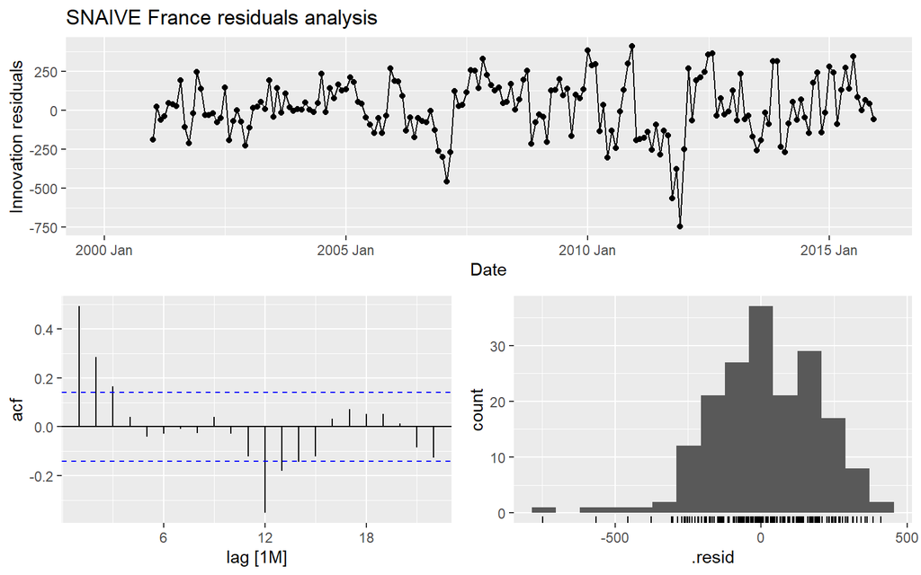

```r
gg_tsresiduals(data_fit_fr_n) + labs(title = "SNAIVE France residuals analysis")
```

## 4.5 Lichtenstein

### **Testing Models**

Based on the previous analysis Lichtenstein data is a NON stationary time series, so we had to difference or log the data to make it stationary before using our models. We tried both, and it seemed like using the log of the data worked best.

Another thing to mention about Lichtenstein, is that for the ETS, ARIMA and SNaive models, we decided to train them only after 2010. We made this decision because before 2010, the data was very different (upward trending at a much higher level) and thought that if the models looked at that period, they would probably not produce accurate results.

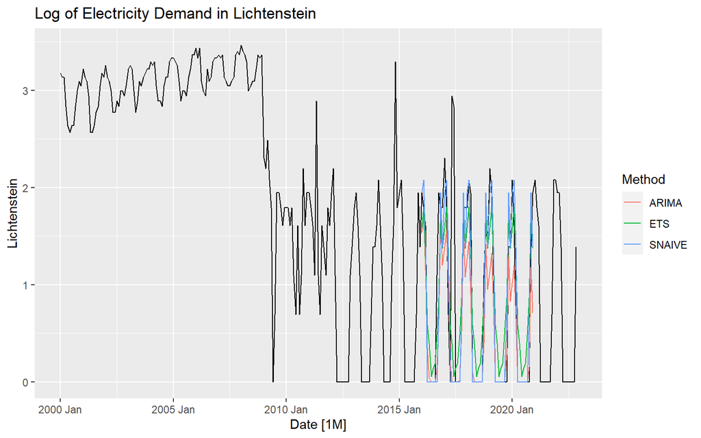

### **Measuring Model Accuracy**

In our case S-Naive outperform during the model selection and analysis of accuracy. However S-Naive method may perform well for the time period that we have train our data, but it is important to note that it has some limitations. Indeed, it assumes that historical patterns will repeat exactly in the future, which may not always hold. The S-Naive method may not account for underlying factors or trends that could impact future outcomes. Thus, there is an increased risk of inaccurate forecasts if the method is blindly applied. ETS could be great models based on a trade off between forecasting error and model complexity. ETS model has the second lowest RMSE and MAE which makes him a good candidate. In order to select a model, we can analyse residuals of Snaive.

| .model | .type | ME | RMSE | MAE | MPE | MAPE | MASE | RMSSE | ACF1 |
| --- | --- | --- | --- | --- | --- | --- | --- | --- | --- |
| ARIMA(Lichtenstein) | Test | 0.4560409 | 0.7600371 | 0.5055350 | NaN | Inf | NaN | NaN | 0.3101830 |
| ETS(Lichtenstein) | Test | 0.0076093 | 0.6384691 | 0.4181878 | -Inf | Inf | NaN | NaN | 0.3882763 |
| SNAIVE(Lichtenstein) | Test | 0.0878665 | 0.6333824 | 0.2931107 | -Inf | Inf | NaN | NaN | 0.4103591 |

```r
#report(data_fit_Licht_n)
#report(data_fit_Licht_e)
```

### **Residuals**

It is interesting to examine any outliers or extreme values in the residuals. The ACF analysis for SNaive shows Positive correlations between the ts and its lags. The result shows that there’s correlation between thoses values. Thus, each observation in the ts can be considered related to the previous values. Concerning the residual, it should ideally appear random, in our case residuals are chinked around zero for SNaive model, thus those might shows autocorrelation.

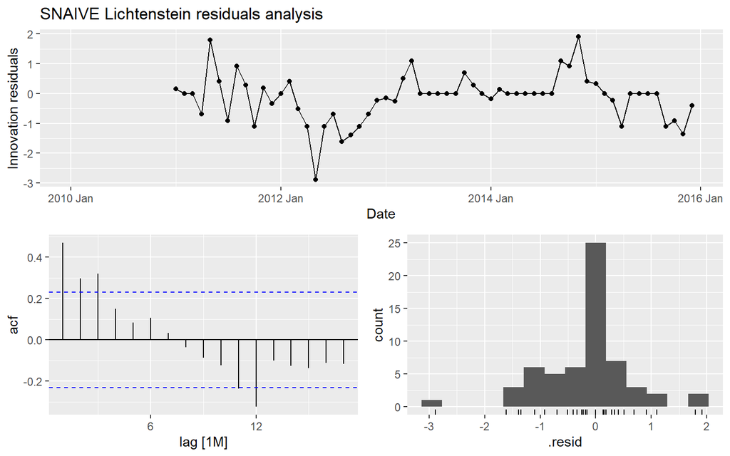

## 4.6 Total

```r
Total_since_2015 <- data_elec %>% select(Date,Total) %>% filter(Date >= as.Date("2015-01-01"))
```

### **Testing Models**

Below is the plot of how well each model fits the data based on a 60-period prediction starting from 2016.

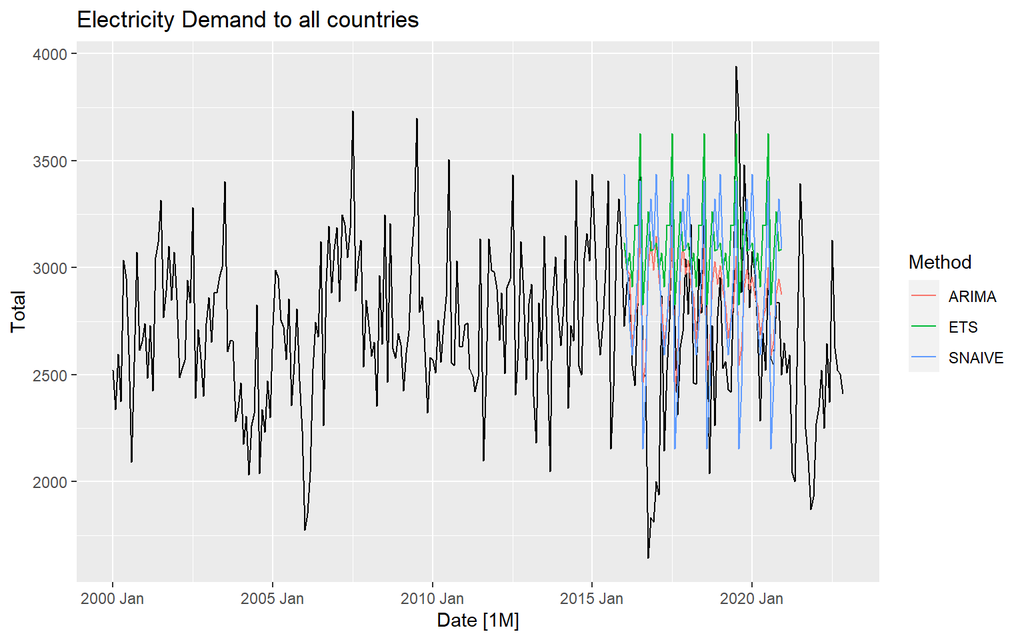

```r
#Split the data
training_tot <- data_elec %>% select(Date, Total) %>%  filter(Date < as.Date("2016-01-01"))
test_tot <- data_elec %>% select(Date, Total) %>% filter(Date >= as.Date("2016-01-01"))

# Fit ARIMA model and generate forecasts
data_fit_tot_a <- training_tot %>%
  model(ARIMA(Total))
forecasts_tot_a <- data_fit_tot_a %>%
  forecast(h = 60)

# Fit ETS model and generate forecasts
data_fit_tot_e <- training_tot %>%
  model(ETS(Total))
forecasts_tot_e <- data_fit_tot_e %>%
  forecast(h = 60)

# Fit seasonal naive model and generate forecasts
data_fit_tot_n <- training_tot %>%
  model(SNAIVE(Total))
forecasts_tot_n <- data_fit_tot_n %>%
  forecast(h = 60)

# Combine forecasts into a single data frame
all_forecasts_tot <- bind_rows(
  data.frame(Date = forecasts_tot_a$Date, Method = "ARIMA", Forecast = forecasts_tot_a$.mean),
  data.frame(Date = forecasts_tot_e$Date, Method = "ETS", Forecast = forecasts_tot_e$.mean),
  data.frame(Date = forecasts_tot_n$Date, Method = "SNAIVE", Forecast = forecasts_tot_n$.mean))


# Plot all three sets of forecasts together
data_elec %>% autoplot(Total) +
  geom_line(data = all_forecasts_tot, aes(x = Date, y = Forecast, color = Method)) +
  labs(title = "Electricity Demand to all countries")
```

### **Measuring Model Accuracy**

According to the accuracy table below, RMSE, MAE, as well as AIC, AICc, and BIC, ARIMA has the lowest values on the test data than the ETS model.

```r
#Accuracy
total_accuracy_a <-accuracy(forecasts_tot_a, test_tot)

total_accuracy_e <-accuracy(forecasts_tot_e, test_tot)

total_accuracy_n <-accuracy(forecasts_tot_n, test_tot)

total_accuracy_table <- rbind(
  data.frame(total_accuracy_a),
  data.frame(total_accuracy_e),
  data.frame(total_accuracy_n))
```

| .model | .type | ME | RMSE | MAE | MPE | MAPE | MASE | RMSSE | ACF1 |
| --- | --- | --- | --- | --- | --- | --- | --- | --- | --- |
| ARIMA(Total) | Test | -152.5501 | 469.2775 | 322.1278 | -8.530677 | 13.59182 | NaN | NaN | 0.5885794 |
| ETS(Total) | Test | -416.7913 | 578.6994 | 472.6052 | -18.311113 | 19.85636 | NaN | NaN | 0.5109384 |
| SNAIVE(Total) | Test | -221.6833 | 564.7462 | 416.0833 | -10.958780 | 17.23146 | NaN | NaN | 0.5163818 |

```
## Series: Total
## Model: ARIMA(1,0,1)(2,0,0)[12] w/ mean
##
## Coefficients:
##          ar1      ma1    sar1    sar2  constant
##       0.7159  -0.2076  0.3750  0.3755  195.5746
## s.e.  0.0912   0.1344  0.0685  0.0708   11.2588
##
## sigma^2 estimated as 63131:  log likelihood=-1335.72
## AIC=2683.45   AICc=2683.9   BIC=2702.99
```

```
## Series: Total
## Model: ETS(A,N,A)
##   Smoothing parameters:
##     alpha = 0.5690082
##     gamma = 0.0002217215
##
##   Initial states:
##      l[0]     s[0]     s[-1]    s[-2]     s[-3]     s[-4]    s[-5]    s[-6]
##  2735.222 -30.5261 -39.40677 146.1547 -77.94267 -290.9088 509.1663 81.12738
##     s[-7]     s[-8]     s[-9]   s[-10]    s[-11]
##  83.81698 -205.6554 -47.17994 -126.659 -1.986777
##
##   sigma^2:  60986.36
##
##      AIC     AICc      BIC
## 3140.436 3143.164 3189.299
```

### **Residuals**

The output below also suggests that the ARIMA model did well in capturing all the dynamics in data, as the residuals seem to be white noise.

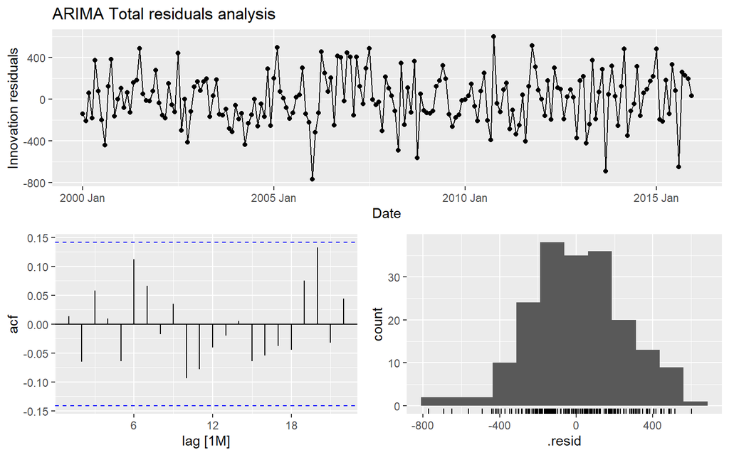

```r
gg_tsresiduals(data_fit_tot_a) + labs(title = "ARIMA Total residuals analysis")
```

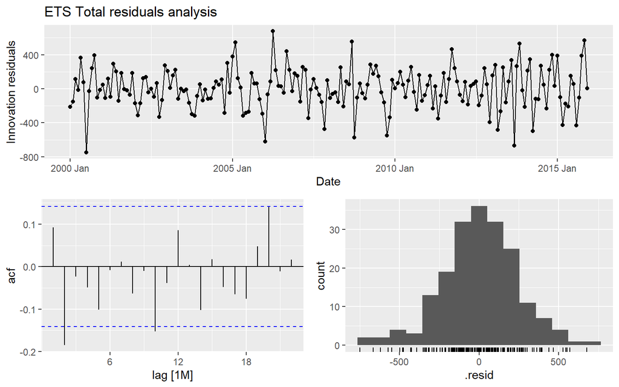

```r
gg_tsresiduals(data_fit_tot_e) + labs(title = "ETS Total residuals analysis")
```

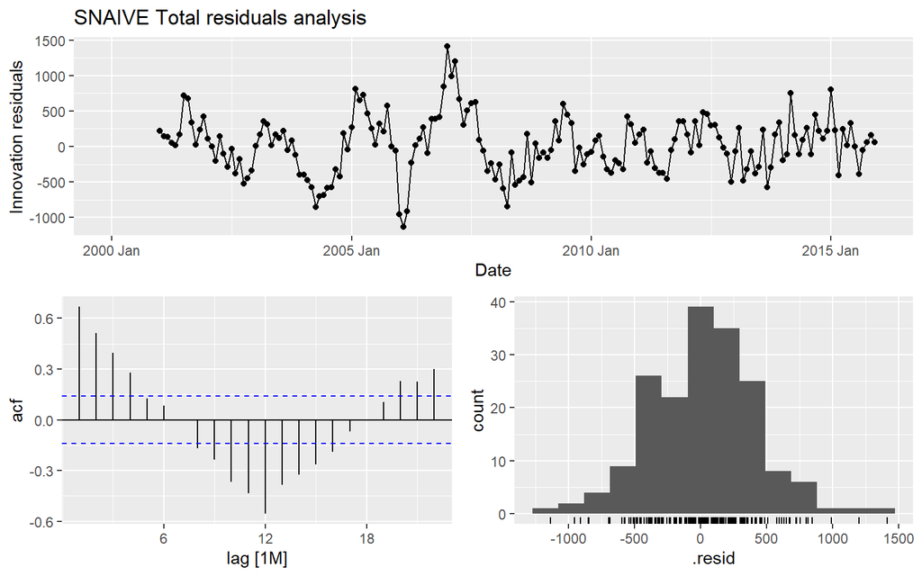

```r
gg_tsresiduals(data_fit_tot_n) + labs(title = "SNAIVE Total residuals analysis")
```

## Result

All of these metrics are important for evaluating forecast accuracy. Still, our goal is to obtain the most accurate forecast. Therefore, we give more weight to RMSE and MAE metrics than AIC. As a result, the ARIMA model is selected to forecast the electricity demand in Italy and the Total, and ETS model is selected to forecast in Germany, Austria and France. Finally, S-Naive is selected to forecast in Lichtenstein.

# 5. Forecast

For each of our country forecasts, we have decided to use the model with the lowest RMSE as shown in the previous section. This is because we want our models to be as “accurate” as possible, in away that minimizes the error/distance between our forecast values and the actual values.

Below, for each country, you can see a residual analysis for every selected model, a graph of the forecast, and finally the forecast table. The outcome of the residual analysis is to confirm that the model has done a good job fitting the data, and more specifically, here’s what we obtained from it:

A good model fit has the following characteristics in terms of its residuals:

- The residuals are distributed symmetrically, in a shape that resembles a Normal distribution.
- Low ACF (autocorrelation) in the first few lags.
- No Heteroskedasticity: the variance of the residuals is constant.
- There is no trend in the residuals.

In essence, what this all means, is that the residuals are white noise. Let’s now look at the results for each country, and make some more specific comments:

## 5.1 Germany

We fit Germany electricity demand data using the ETS model.

```r
# Modelling ARIMA automatically
ets_germany <- data_elec %>%
  select(Germany) %>%
  model(ets = ETS(Germany))

# Forecasting using the models
forecast_ets_germany <- ets_germany %>% forecast(h = 13) %>% hilo(90)
```

### **Checking Residuals**

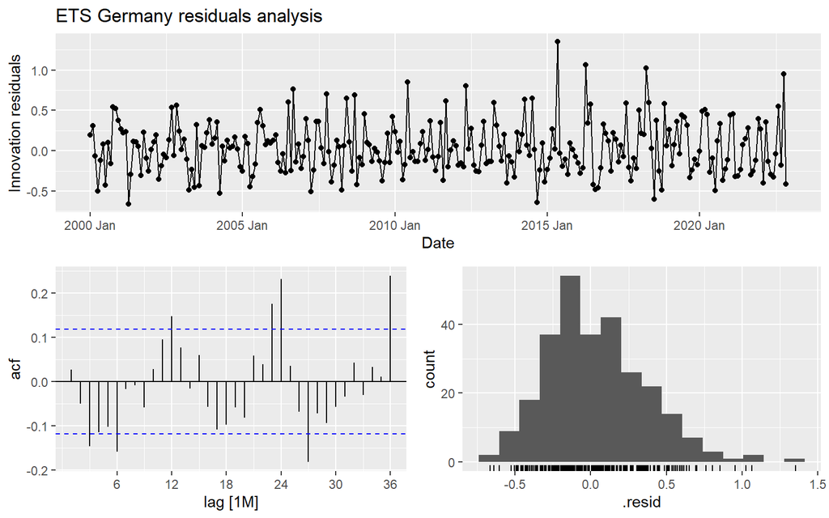

```r
ets_germany %>% gg_tsresiduals(lag_max = 36) + labs(title = "ETS Germany residuals analysis")
```

### **Graphing the forecast**

[figure not shown]

```r
ets_germany %>% forecast(h = 13) %>% autoplot(Germany_since_2015) +
  labs(title = "ETS Forecast for Germany")
```

```r
#Extracting the forecasted values
forecast_table_germany_e <- data.frame(Model = c("ETS"),
                              Forecast_Values = c(forecast_ets_germany))



forecast_table_germany_e <- forecast_table_germany_e %>% select(Forecast_Values.Date,Forecast_Values..mean, Forecast_Values.90.)
forecast_table_germany_e$Country <- "Germany"

colnames(forecast_table_germany_e)[1] <- "Month"
colnames(forecast_table_germany_e)[2] <- "PF"
colnames(forecast_table_germany_e)[3] <- "CI"
```

### **Forecast Table**

The resulting forecast table for Germany is shown below.

```r
#forecast_table_germany_e
kbl(forecast_table_germany_e) %>%
  kable_styling(fixed_thead = T)
```

| Month | PF | CI | Country |
| --- | --- | --- | --- |
| 2022 Dec | 157.1304 | [69.352709, 244.9081]90 | Germany |
| 2023 Jan | 134.0659 | [38.462369, 229.6695]90 | Germany |
| 2023 Feb | 104.7389 | [15.969441, 193.5083]90 | Germany |
| 2023 Mar | 133.3176 | [3.902624, 262.7325]90 | Germany |
| 2023 Apr | 272.8334 | [-23.725170, 569.3920]90 | Germany |
| 2023 May | 489.8151 | [-97.314650, 1076.9448]90 | Germany |
| 2023 Jun | 429.4505 | [-132.035138, 990.9361]90 | Germany |
| 2023 Jul | 429.2634 | [-177.873964, 1036.4007]90 | Germany |
| 2023 Aug | 398.2749 | [-207.194123, 1003.7439]90 | Germany |
| 2023 Sep | 282.1175 | [-176.503436, 740.7385]90 | Germany |
| 2023 Oct | 218.3380 | [-159.623254, 596.2992]90 | Germany |
| 2023 Nov | 176.7443 | [-147.928838, 501.4175]90 | Germany |
| 2023 Dec | 156.4080 | [-147.602206, 460.4183]90 | Germany |